# Data Visualisation with GGplot2 - Project

## 5. Solution Implementation

### 5.a) Questions

```r
# 1. How many bookings were cancelled? Let's plot a Bar chart
# ---

library(ggplot2)

cancellation_df <- group_by(new_df, is_canceled) %>%
  summarise( count = length(is_canceled) )

cancellation_df$is_canceled <- as.character(cancellation_df$is_canceled)
cancellation_df
```

| is_canceled | count |
| --- | --- |
| 0 | 75027 |
| 1 | 44191 |

[figure not shown]

```r
ggplot(data = cancellation_df, aes(x="", y = count, fill = is_canceled)) +
  geom_bar(
    stat="identity", width=0.5, color = "white"
  ) +
  coord_polar("y") +
  geom_text(
    aes(label = paste0(count)), position = position_stack(vjust = 0.5)
  ) +
  scale_fill_brewer(palette="Set1") +
  labs(
    title = "Booking ratio of hotel types"
  ) +
  theme_void()
```

Observation: - 44,191 bookings were cancelled

```r
new_df_not_cancelled <- new_df %>%
  filter(is_canceled == 0)

dim(new_df_not_cancelled)
```

```
[1] 75027    32
```

```r
# 2. What was the booking ratio between resort hotel and city hotel?
# ---

hotel_df <- group_by(new_df_not_cancelled, hotel) %>%
  summarise(

    hotel_ratio = (
      round((length(hotel) / length(new_df_not_cancelled$hotel)) * 100, 0)
      )

    )

hotel_df
```

| hotel | hotel_ratio |
| --- | --- |
| City Hotel | 62 |
| Resort Hotel | 38 |

```r
NA
```

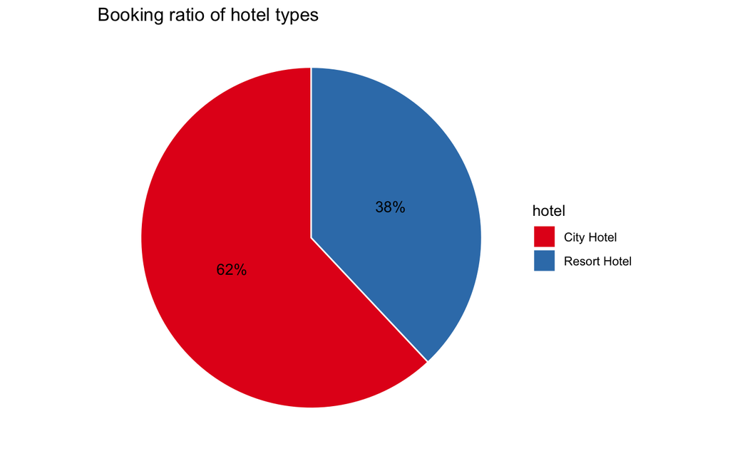

```r
ggplot(data = hotel_df, aes(x="", y = hotel_ratio, fill = hotel)) +
  geom_bar(
    stat="identity", width=0.5, color = "white"
  ) +
  coord_polar("y") +
  geom_text(
    aes(label = paste0(hotel_ratio, "%")), position = position_stack(vjust = 0.5)
  ) +
  scale_fill_brewer(palette="Set1") +
  labs(
    title = "Booking ratio of hotel types"
  ) +
  theme_void()
```

Observation: - City Hotels & Resort Hotels had a ration of 62 to 38

```r
# 3. What was the percentage of booking for each year?
# ---

arrival_date_year_df <- group_by(new_df_not_cancelled, arrival_date_year) %>%
  summarise(

    bookings_percentage = (
      round((length(arrival_date_year) / length(new_df_not_cancelled$arrival_date_year)) * 100, 0)
      )

    )

arrival_date_year_df$arrival_date_year <- as.character(arrival_date_year_df$arrival_date_year)
arrival_date_year_df
```

| arrival_date_year | bookings_percentage |
| --- | --- |
| 2015 | 18 |
| 2016 | 48 |
| 2017 | 33 |

```r
NA
```

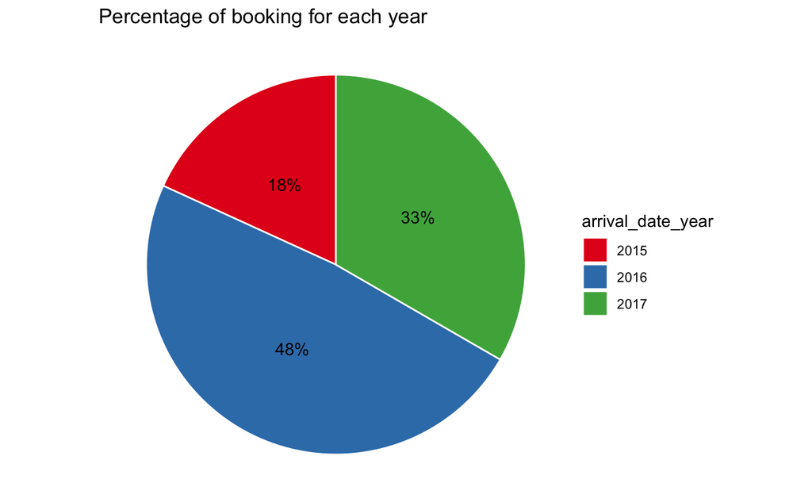

```r
ggplot(data = arrival_date_year_df, aes(x="", y = bookings_percentage, fill = arrival_date_year)) +
  geom_bar(
    stat="identity", width=0.5, color = "white"
  ) +
  coord_polar("y") +
  geom_text(
    aes(label = paste0(bookings_percentage, "%")), position = position_stack(vjust = 0.5)
  ) +
  scale_fill_brewer(palette="Set1") +
  labs(
    title = "Percentage of booking for each year"
  ) +
  theme(
    plot.title = element_text(hjust = 0.5, size=16, family="Times New Roman"),
    axis.text.x = element_text(angle = 45, hjust = 1)
  ) +
  theme_void()
```

Observation: - 2016 had the most bookings, taking up 48% of all bookings

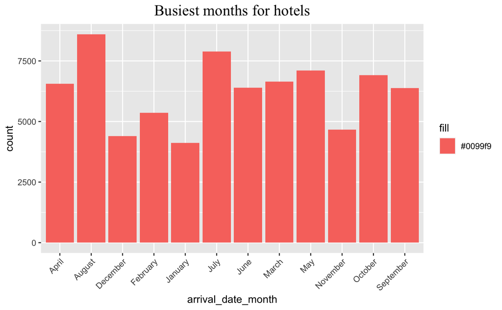

```r
# 4. Which were the busiest months for hotels?
# ---

ggplot(data = new_df_not_cancelled, aes(x = arrival_date_month, fill='#0099f9') ) +
  geom_bar() +
  labs(
    title = "Busiest months for hotels"
  ) +
  theme(
    plot.title = element_text(hjust = 0.5, size=16, family="Times New Roman"),
    axis.text.x = element_text(angle = 45, hjust = 1)
  )
```

Observation: - The busiest months were August, July and May in that order

```r
# 5. From which top 3 countries did most guests come from?
# ---

country_df <- group_by(new_df_not_cancelled, country) %>%
  summarise( country_count = length(country) )

country_df <- country_df[order(-country_df$country_count),]
country_df
```

| country | country_count |
| --- | --- |
| PRT | 21008 |
| GBR | 9665 |
| FRA | 8466 |
| ESP | 6371 |
| DEU | 6068 |
| IRL | 2540 |
| ITA | 2428 |
| BEL | 1868 |
| NLD | 1717 |
| USA | 1596 |

[output cut: 156 more lines]

```r
NA
```

Observation: - PRT, GBR and FRA were the top 3 countries

```r
# 6.a) How long do most people stay in hotels?
#   b) By city and resort? Separate the data by hotel
# ---

stay_df <- new_df_not_cancelled %>%
  mutate(total_stay = stays_in_weekend_nights + stays_in_week_nights) %>%
  group_by(hotel) %>%
  summarise(avg_stay = round(mean(total_stay), 0))

stay_df
```

| hotel | avg_stay |
| --- | --- |
| City Hotel | 3 |
| Resort Hotel | 4 |

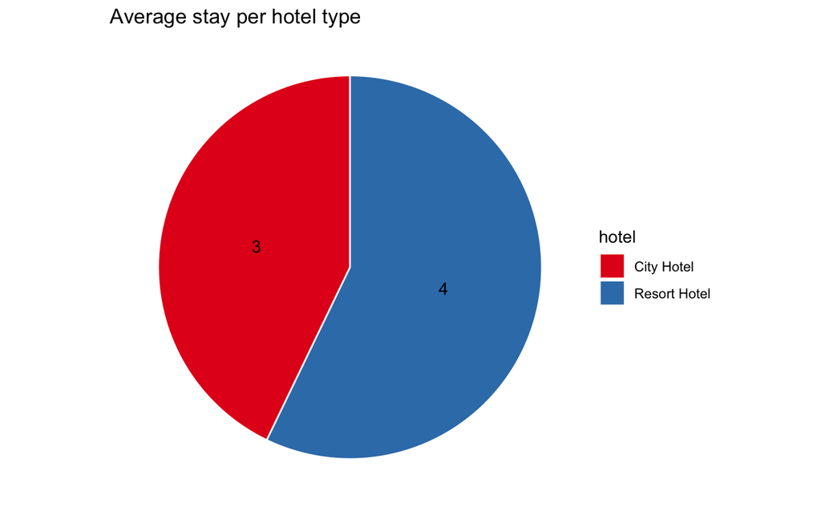

```r
ggplot(data = stay_df, aes(x="", y = avg_stay, fill = hotel)) +
  geom_bar(
    stat="identity", width=0.5, color = "white"
  ) +
  coord_polar("y") +
  geom_text(
    aes(label = paste0( avg_stay )), position = position_stack(vjust = 0.5)
  ) +
  scale_fill_brewer(palette="Set1") +
  labs(
    title = "Average stay per hotel type"
  ) +
  theme_void()
```

Observation: - Average stay of Resort hotels was 4 nights while that of City hotels was 3 nights

```r
# 7. Which was the most booked accommodation type (Single, Couple, Family)?
# ---

accommodation_type_df <- new_df_not_cancelled %>%
  mutate(accommodation_type =
           case_when(
             new_df_not_cancelled$adults == 2 & new_df_not_cancelled$babies == 0 & new_df_not_cancelled$children == 0 ~ "Couple",
             new_df_not_cancelled$adults == 1 & new_df_not_cancelled$babies == 0 & new_df_not_cancelled$children == 0 ~ "Single",
             TRUE ~ "Family"
           )
  ) %>%
  group_by(accommodation_type)

accommodation_types <- accommodation_type_df %>%
  group_by(accommodation_type) %>%
  summarise(
    count = length(accommodation_type)
  )

accommodation_types
```

| accommodation_type | count |
| --- | --- |
| Couple | 49136 |
| Family | 9869 |
| Single | 16022 |

Observation: - Couple bookings were the most

## 7. Summary of Findings & Recommendations

- Couple bookings were the most (65%)
- 44,191 bookings were cancelled, that’s about 37%
- Average stay of Resort hotels was 4 nights while that of City hotels was 3 nights
- PRT, GBR and FRA were the top 3 countries from which guests came from
- The busiest months were August, July and May in that order
- 2016 had the most bookings, taking up 48% of all bookings
- Ratio of City Hotels to Resort Hotels bookings was 62 to 38

## 8. Follow up questions

a). Did we have the right data? Yes b). Do we need other data to answer our question? No c). Did we have the right question? Yes